# Final Project

Anisha Choudhury

2023-12-08

## R Markdown

```r
#import library
library(ggplot2)
library(tidyr)
library(dplyr)
XYZ <- read.csv("/Users/anishachoudhury/Desktop/DATA 180 Anisha/DATA-180-Anisha/loan_default_data_set.csv",header=T)
#head(XYZ)
dim(XYZ)
```

```
## [1] 20000    21
```

```r
nrow(XYZ)
```

```
## [1] 20000
```

```r
ncol(XYZ)
```

```
## [1] 21
```

```r
colnames(XYZ)
```

```
##  [1] "tot_balance"                     "avg_bal_cards"
##  [3] "credit_age"                      "credit_age_good_account"
##  [5] "credit_card_age"                 "num_acc_30d_past_due_12_months"
##  [7] "num_acc_30d_past_due_6_months"   "num_mortgage_currently_past_due"
##  [9] "tot_amount_currently_past_due"   "num_inq_12_month"
## [11] "num_card_inq_24_month"           "num_card_12_month"
## [13] "num_auto_.36_month"              "uti_open_card"
## [15] "pct_over_50_uti"                 "uti_max_credit_line"
## [17] "pct_card_over_50_uti"            "ind_XYZ"
## [19] "rep_income"                      "rep_education"
## [21] "Def_ind"
```

There are 20,000 rows and 21 columns. (c)Type of data are numerical, character and integer.

```r
colSums(is.na(XYZ)) / nrow(XYZ) * 100 #all columns percentage of missing values
```

```
##                     tot_balance                   avg_bal_cards
##                           0.000                           0.000
##                      credit_age         credit_age_good_account
##                           0.000                           0.000
##                 credit_card_age  num_acc_30d_past_due_12_months
##                           0.000                           0.000
##   num_acc_30d_past_due_6_months num_mortgage_currently_past_due
##                           0.000                           0.000
##   tot_amount_currently_past_due                num_inq_12_month
##                           0.000                           0.000
##           num_card_inq_24_month               num_card_12_month
##                           0.000                           0.000
##              num_auto_.36_month                   uti_open_card
##                           0.000                           0.000
##                 pct_over_50_uti             uti_max_credit_line
##                           0.000                           0.000
##            pct_card_over_50_uti                         ind_XYZ
##                           9.790                           0.000
##                      rep_income                   rep_education
##                           7.795                           0.000
##                         Def_ind
##                           0.000
```

```r
XYZ <- drop_na(XYZ)
dim(XYZ) #16653 x 21 are the new dimensions
```

```
## [1] 16653    21
```

```r
summary(XYZ) #2(a)
```

```
##   tot_balance     avg_bal_cards     credit_age    credit_age_good_account
##  Min.   :     0   Min.   :    0   Min.   :  0.0   Min.   :  0.0
##  1st Qu.: 92142   1st Qu.:10135   1st Qu.:231.0   1st Qu.:120.0
##  Median :107740   Median :12237   Median :281.0   Median :146.0
##  Mean   :107503   Mean   :12226   Mean   :280.9   Mean   :146.2
##  3rd Qu.:122932   3rd Qu.:14297   3rd Qu.:330.0   3rd Qu.:172.0
##  Max.   :200000   Max.   :25000   Max.   :550.0   Max.   :300.0
##  credit_card_age num_acc_30d_past_due_12_months num_acc_30d_past_due_6_months
##  Min.   :  0.0   Min.   :0.0000                 Min.   :0.00000
##  1st Qu.:242.0   1st Qu.:0.0000                 1st Qu.:0.00000
##  Median :285.0   Median :0.0000                 Median :0.00000
##  Mean   :285.4   Mean   :0.1579                 Mean   :0.02936
##  3rd Qu.:330.0   3rd Qu.:0.0000                 3rd Qu.:0.00000
##  Max.   :550.0   Max.   :5.0000                 Max.   :2.00000
##  num_mortgage_currently_past_due tot_amount_currently_past_due
##  Min.   :0.0000                  Min.   :    0.0
##  1st Qu.:0.0000                  1st Qu.:    0.0
##  Median :0.0000                  Median :    0.0
##  Mean   :0.0299                  Mean   :  354.2
##  3rd Qu.:0.0000                  3rd Qu.:    0.0
##  Max.   :1.0000                  Max.   :35000.0
##  num_inq_12_month  num_card_inq_24_month num_card_12_month num_auto_.36_month
##  Min.   : 0.0000   Min.   : 0.000        Min.   :0.0000    Min.   :0.000
##  1st Qu.: 0.0000   1st Qu.: 0.000        1st Qu.:0.0000    1st Qu.:0.000
##  Median : 0.0000   Median : 0.000        Median :0.0000    Median :0.000
##  Mean   : 0.6133   Mean   : 1.044        Mean   :0.2723    Mean   :0.165
##  3rd Qu.: 1.0000   3rd Qu.: 1.000        3rd Qu.:1.0000    3rd Qu.:0.000
##  Max.   :10.0000   Max.   :18.000        Max.   :3.0000    Max.   :2.000
##  uti_open_card    pct_over_50_uti  uti_max_credit_line pct_card_over_50_uti
##  Min.   :0.0000   Min.   :0.0000   Min.   :0.0000      Min.   :0.0000
##  1st Qu.:0.4048   1st Qu.:0.4011   1st Qu.:0.3778      1st Qu.:0.4643
##  Median :0.4909   Median :0.4855   Median :0.4649      Median :0.5518
##  Mean   :0.4914   Mean   :0.4842   Mean   :0.4653      Mean   :0.5511
##  3rd Qu.:0.5783   3rd Qu.:0.5679   3rd Qu.:0.5541      3rd Qu.:0.6384
##  Max.   :1.0000   Max.   :0.9294   Max.   :1.0000      Max.   :1.0000
##     ind_XYZ         rep_income     rep_education         Def_ind
##  Min.   :0.0000   Min.   : 20000   Length:16653       Min.   :0.0000
##  1st Qu.:0.0000   1st Qu.:143751   Class :character   1st Qu.:0.0000
##  Median :0.0000   Median :166630   Mode  :character   Median :0.0000
##  Mean   :0.2487   Mean   :166504                      Mean   :0.1019
##  3rd Qu.:0.0000   3rd Qu.:189020                      3rd Qu.:0.0000
##  Max.   :1.0000   Max.   :300000                      Max.   :1.0000
```

(b)For “num_card_inq_24_month”, the mean is more than the median so it’s right skewed. For “tot_amount_currently_past_due”, the mean is more than median so it’s right shaped. For ‘credit_age’, the median is approximately equal to the mean so it will be bell-shaped.

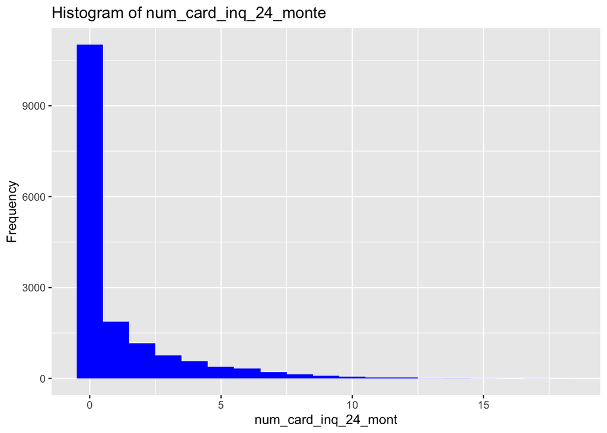

```r
ggplot(XYZ,aes(x=num_card_inq_24_month)) + geom_histogram(fill="blue",binwidth =1) + labs(title = "Histogram of num_card_inq_24_monte", x = "num_card_inq_24_mont", y = "Frequency")
```

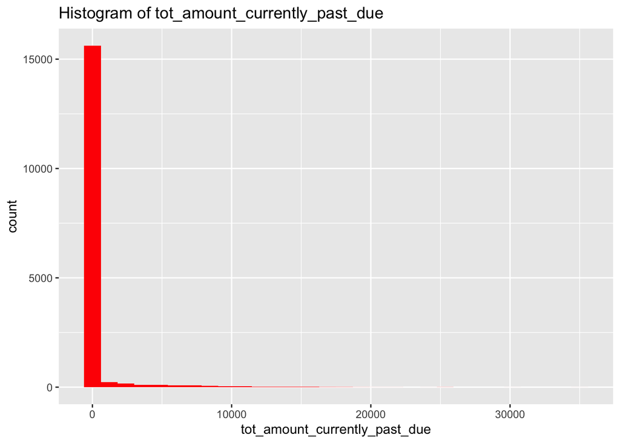

```r
#the plot matches the assumption of num_card_inq_24_month being right skewed.
ggplot(XYZ,aes(x=tot_amount_currently_past_due)) + geom_histogram(fill="red", bins = 30) + labs(title = "Histogram of tot_amount_currently_past_due")
```

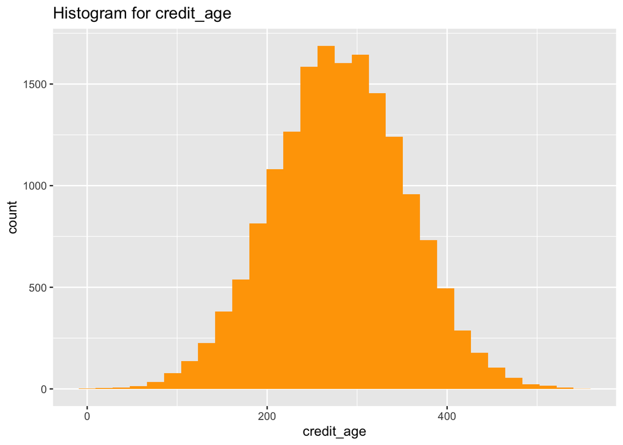

```r
#the plot matches the assumption of tot_amount_currently_past_due being rightly skewed.
ggplot(XYZ,aes(x=credit_age)) + geom_histogram(fill="orange", bins=30) + labs(title = "Histogram for credit_age")
```

```r
#the plot matches the assumption of credit_age being bell-shaped.
```

4. The first method to convert character to numeric can be the function as.numeric. Secondly, we can also use the function transform() method.

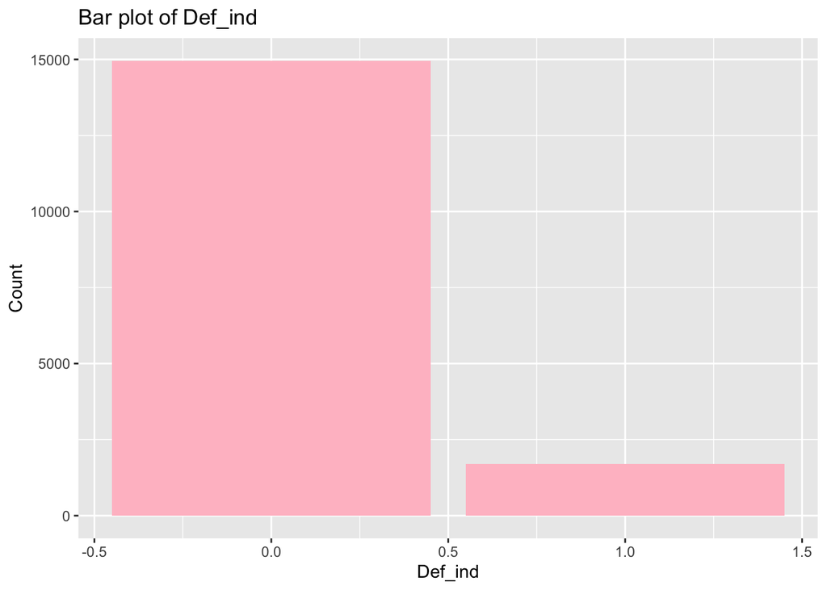

```r
ggplot(XYZ,aes(x=Def_ind)) + geom_bar(fill="pink") + labs(title = "Bar plot of Def_ind", x = "Def_ind", y = "Count")
```

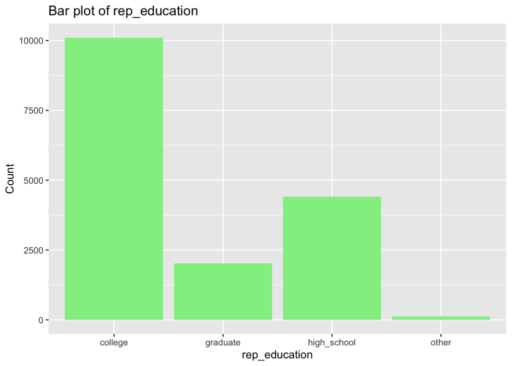

```r
#(a)
ggplot(XYZ,aes(x=rep_education)) + geom_bar(fill="lightgreen") + labs(title = "Bar plot of rep_education", x = "rep_education", y = "Count")
```

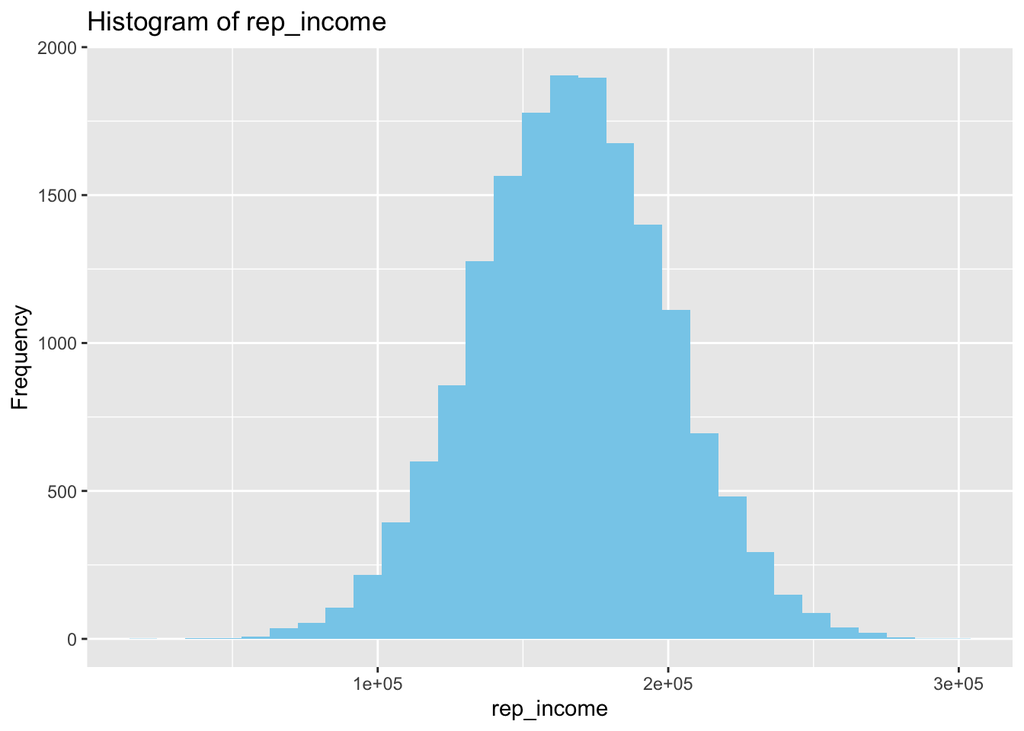

```r
#(b)
ggplot(XYZ,aes(x=rep_income)) + geom_histogram(fill="skyblue") + labs(title = "Histogram of rep_income", x = "rep_income", y = "Frequency")
```

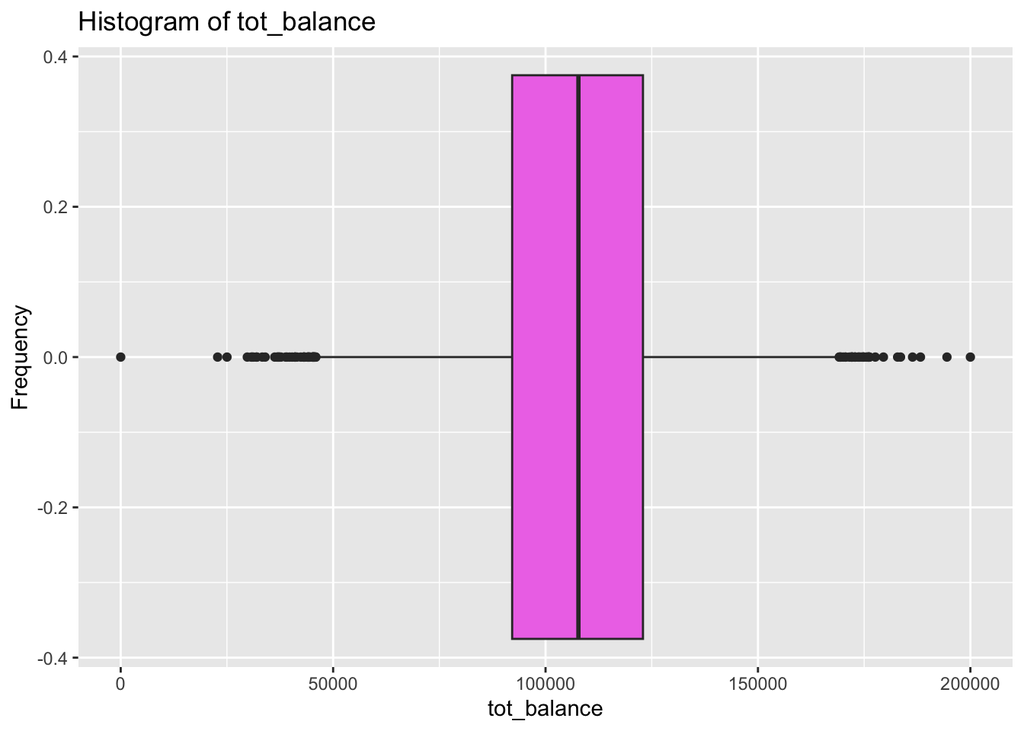

```r
#(c)
ggplot(XYZ,aes(x=tot_balance)) + geom_boxplot(fill="orchid2") + labs(title = "Histogram of tot_balance", x = "tot_balance", y = "Frequency")
```

2(a)The bar graph for “Def_Ind” shows that the larger proportion of accounts were not defaulted after an account was approved and opened with bank XYZ in the past 18 months (b) The bar graph for “rep_education” shows that most applicants’ education level were college graduates, with high school being the next, graduates being the third and lastly others.

```r
summary(XYZ$tot_balance)
```

```
##    Min. 1st Qu.  Median    Mean 3rd Qu.    Max.
##       0   92142  107740  107503  122932  200000
```

```r
boxplot.stats(XYZ$tot_balance)$out
```

```
##  [1]  37213.81 176118.32 175548.20 174991.23  45908.84 172021.49 188251.04
##  [8] 177612.90  30917.23  31931.05  41069.30  31215.30  43069.16  33995.84
## [15]  44202.58  44532.17 174821.66  39126.32  37189.69  45624.69      0.00
## [22]  36256.21  30780.03 176206.95  45371.69 179531.11  45126.65 172831.88
## [29]  37431.07  43972.68  41012.27 176225.82 172820.94  37724.46 173917.16
## [36]  41043.34 170626.70  43349.10 175988.74 182871.57  44179.22  41462.38
## [43]  44474.37 175710.42 169497.88  44099.11  38838.70 172062.06  45218.49
## [50]  45238.39 173751.80 171941.51 200000.00 170562.14 169207.14  22812.25
## [57]  42402.89  45528.07 171547.45  43154.35  45639.00  45068.05 175989.66
## [64] 183558.68 174756.93  29795.50 186386.24 174318.25 172251.35 194485.99
## [71] 173533.11  33319.34  39744.14  45505.23  36839.24 174664.56  36874.44
## [78] 170056.55 169129.42  25018.42 169498.02  45355.74  32057.66 172877.95
## [85] 172258.75  45905.18  43076.09  40345.16
```